# UEP Data Visualization

Clémentine de Montgolfier

2025-05-15

# Préparation des données

Seule modification des données :  
- suppression des parcelles sans identifiant (n = 4)  
- suppression des parcelles non boisées (R non boisé boisable, V non boisable, M terrain de service) (n = 145) mais j’ai gardé les surfaces boisées hors silviculture (n=7)

# Visualisation des données UEP

## Surface terrière moyenne

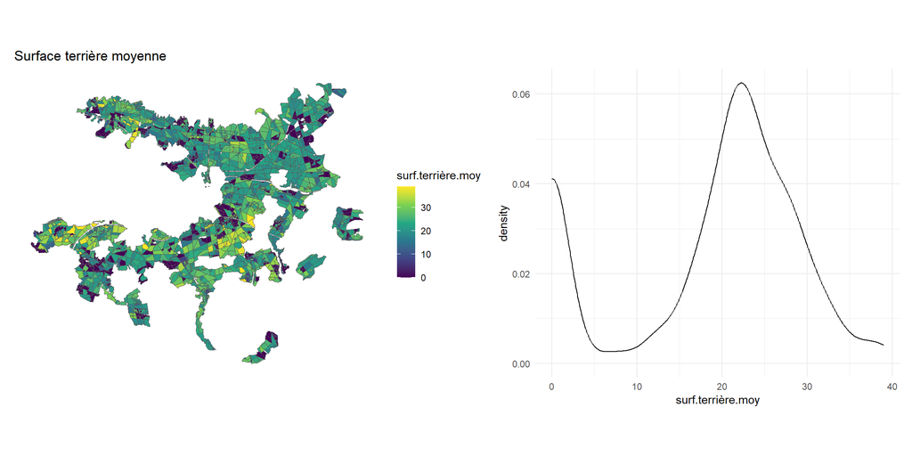

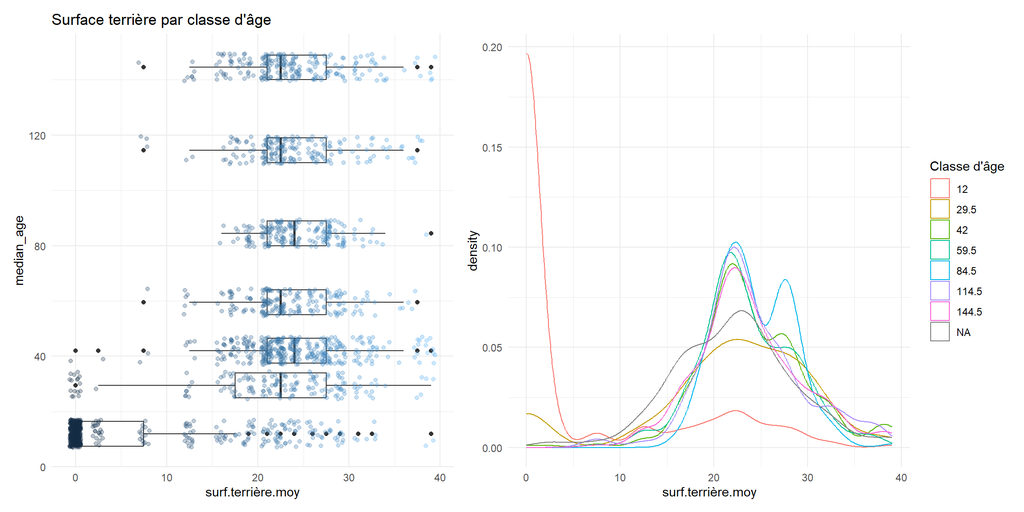

## Essence dominante

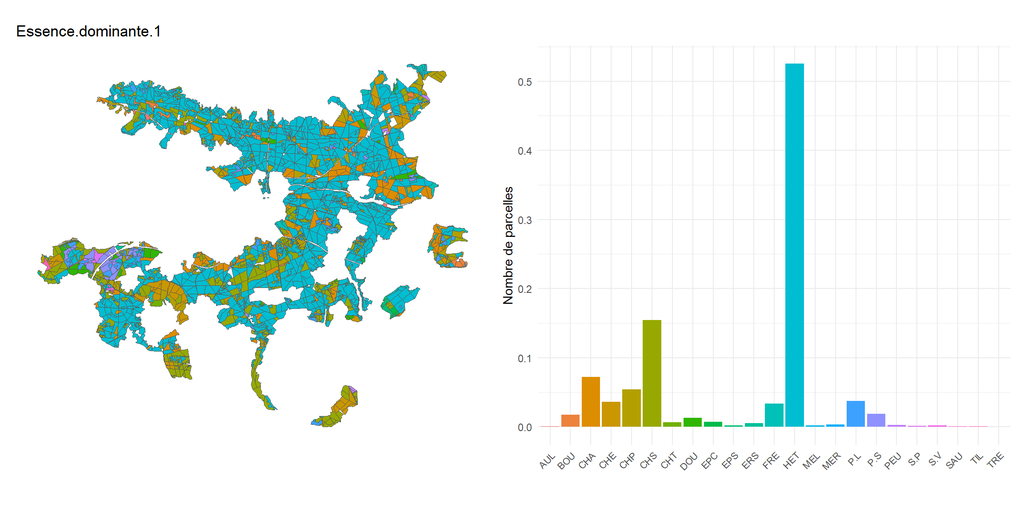

## Type de peuplement

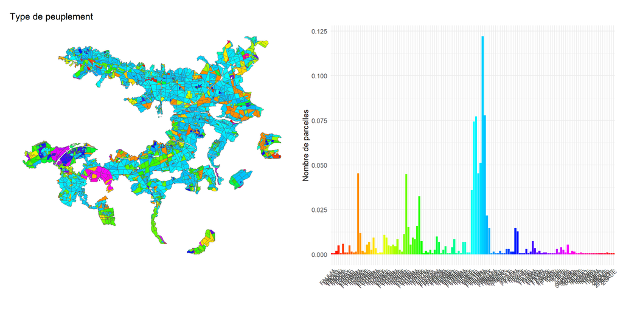

Il y a 26 peuplements qui représentent 80% des placettes.

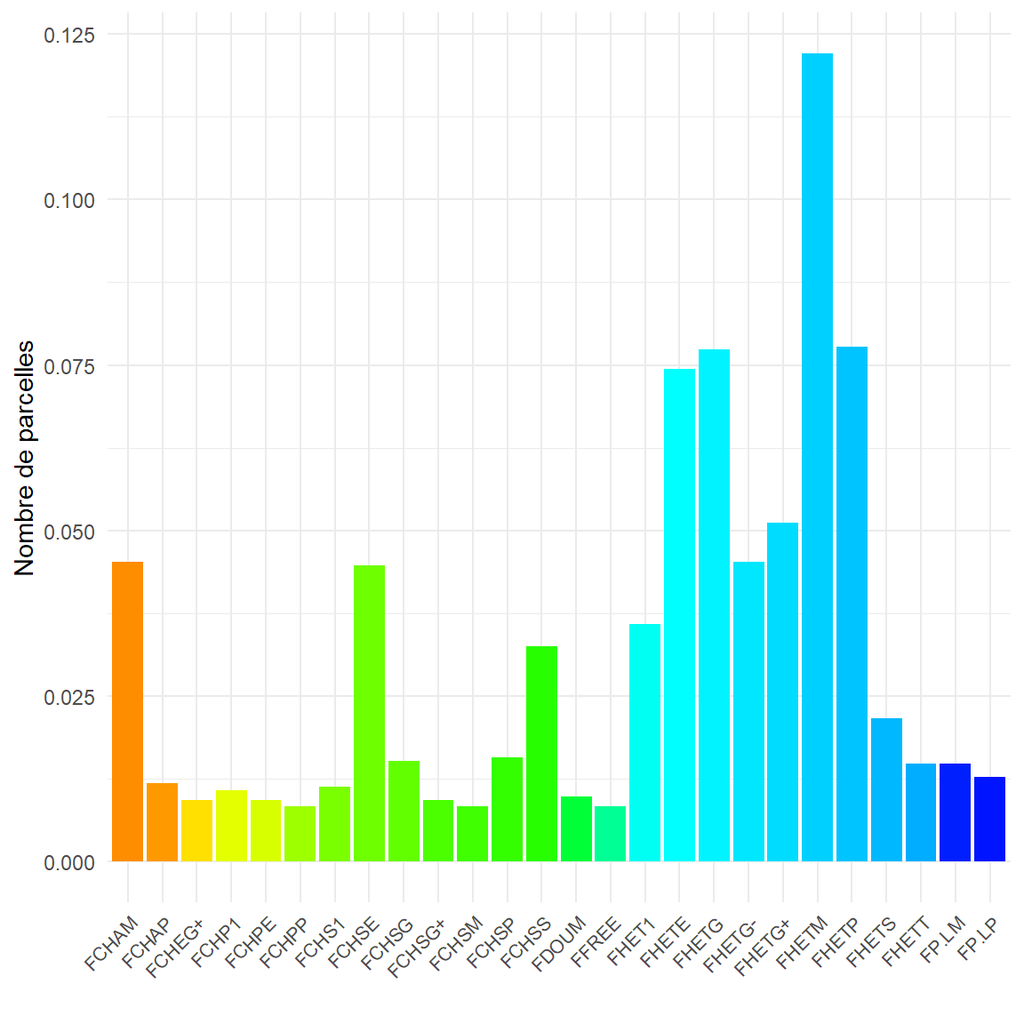

## Classe de catégorie de diamètre dominant

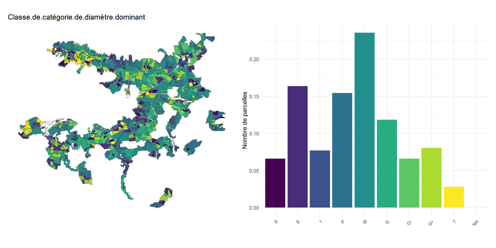

Table CCD: Classe de catégorie de diamètre dominante

| CODE | LIBELLE |
| --- | --- |
| S | REGENERATION (H<3m) |
| E | EDUCATION (non commercialisable; d<10cm) |
| IR | IRREGULIER (pas de diamètre dominant) |
| 1 | PERCHES (10-15cm) |
| P | PETITS BOIS (20-25cm) |
| M | BOIS MOYENS (30-45cm) |
| G | GROS BOIS (50-65cm) |
| G- | proche de 50 cm |
| G+ | proche de 65 cm |
| T | TRES GROS BOIS (70cm et+) |

## Couverture du Hêtre et du Chêne sessile

Chène sessile avec le Chène épdonculé et ensuite Charme

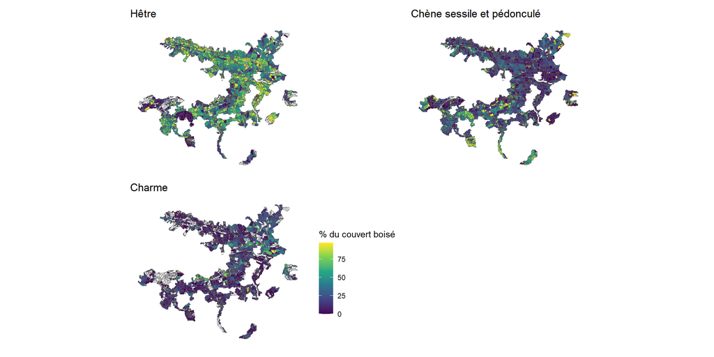

# Difference espèce dominante, espèce objectif

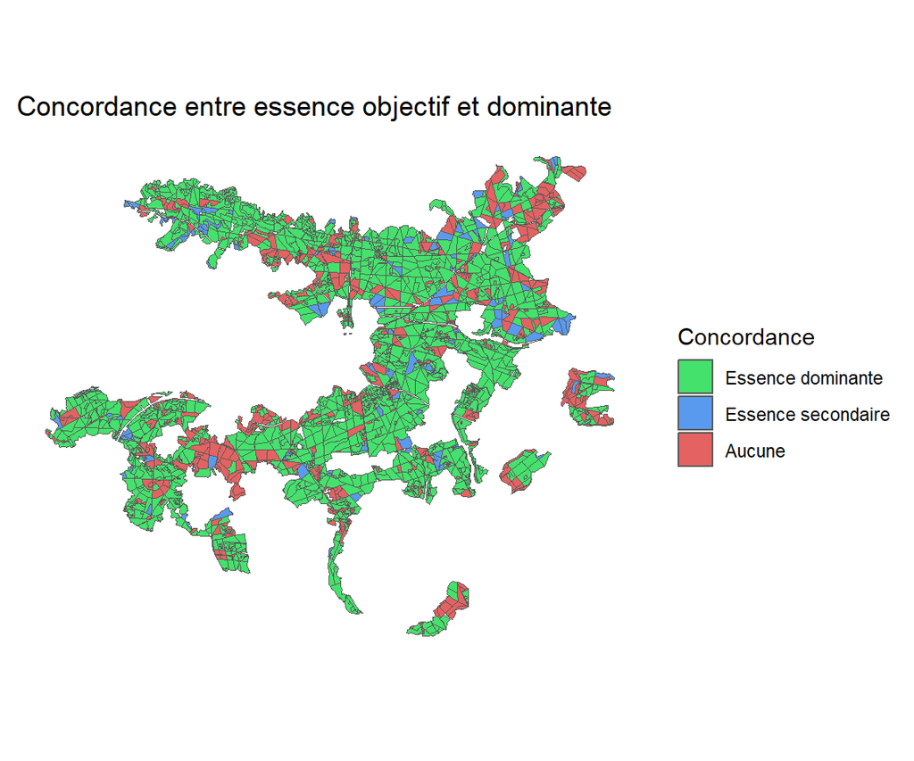

# Essence, dominance et surface terrière

## Essence dominantes

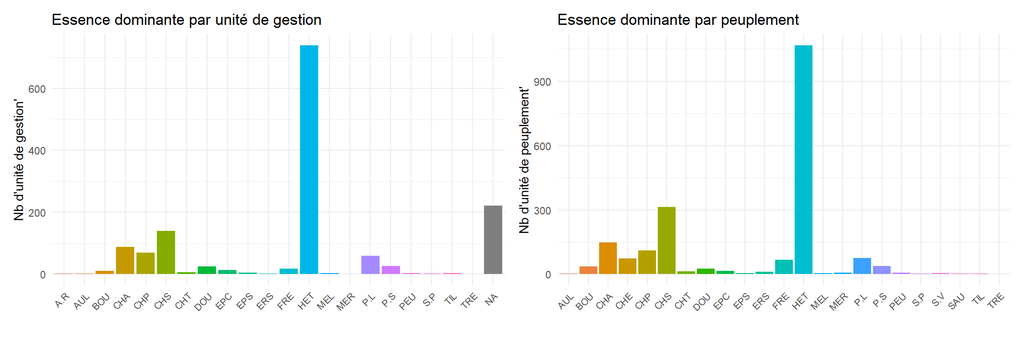

## Surface terrière

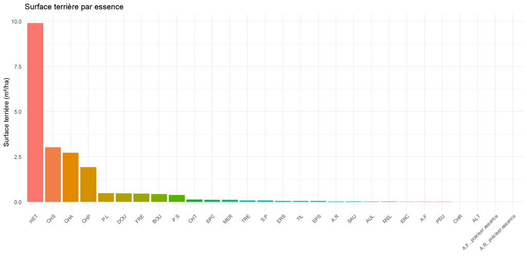

```
## [1] 20.51757
```

Je propose de garder les essences suivantes pour la modélisation : HET, CHS, CHA, CHP, P.L, DOU, FRE, BOU, P.S

## Espèces objectif

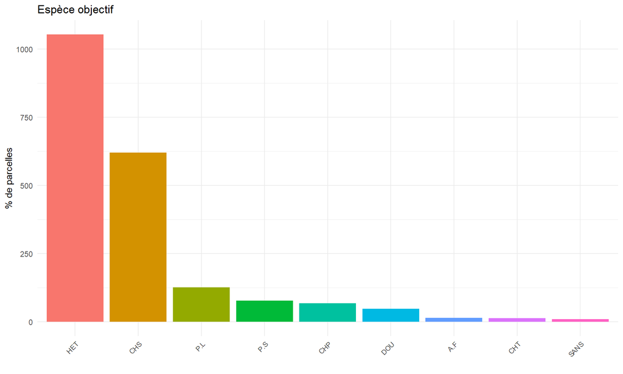

## Correspondance Forceeps

Espèces Retz et correspondance

| X | Forceps_Code | Latin_Name | Retz_Code | French_Name | Freq |
| --- | --- | --- | --- | --- | --- |
| 1 | 0 | Abies alba | S.P | Sapin pectiné | 1 |
| 3 | 2 | Picea abies | EPC | Epicéa commun | 1 |
| 6 | 5 | Pinus sylvestris | P.S | Pin sylvestre | 3 |
| 10 | 9 | Acer pseudoplatanus | ERS | Erable sycomore | 1 |
| 14 | 13 | Betula pendula | BOU | Bouleaux divers | 2 |
| 15 | 14 | Carpinus betulus | CHA | Charme | 2 |
| 16 | 15 | Castanea sativa | CHT | Châtaignier | 2 |
| 18 | 17 | Fagus sylvatica | HET | Hêtre | 3 |
| 19 | 18 | Fraxinus excelsior | FRE | Frênes | 2 |
| 21 | 20 | Populus tremula | TRE | Tremble | 1 |
| 22 | 21 | Quercus petraea | CHS | Chêne sessile | 3 |
| 24 | 23 | Quercus robur | CHP | Chêne pédonculé | 3 |
| 32 | 31 | Pinus nigra | P.L | Pin laricio | 3 |
| 35 | 33 | Pseudotsuga menziesii | DOU | Douglas | 3 |
| 42 | NA | Alnus sp. | AUL | Aulnes divers | 1 |
| 49 | NA | Prunus avium | MER | Merisier | 1 |
| 52 | NA | Populus sp. | PEU | Peupliers divers | 1 |
| 57 | NA | Tilia sp. | TIL | Tilleuls | 1 |
| 62 | NA | Picea sitchensis | EPS | Epicéa de Sitka | 1 |
| 64 | NA | Larix sp. | MEL | Mélèzes divers | 1 |

Pin larico peut-être rattaché à Pinus nigra  
Bouleaux divers peut être associé à Betula pendula

Les autres n’ont qu’un seul critères, qui est essence dominante, dans seulement les placettes ci dessus :

[figure not shown]

Je pense que l’on peut les ignorer pour commencer, car ils ne sont pas représentatifs de la forêt de Retz.

Ce sont 27 placettes (sur 2031 soit 1.33 %) pour une surface de 91.6 ha (sur 1.301527^{4} ha, soit 0.7 %).

```r
forest_data %>%
  filter(Essence.dominante.1 %in% essence_prb) %>%
  select(Identifiant.peuplement.élémentaire, Essence.dominante.1, Essence.dominante.2, Classe.de.catégorie.de.diamètre.dominant, ess.obj,surface.retenue, surf.terrière.moy) %>%
  rename(
    "Identifiant" = Identifiant.peuplement.élémentaire,
    "Esp Dominante 1" = Essence.dominante.1,
    "Esp Dominante 2" = Essence.dominante.2,
    "Diamètre" = Classe.de.catégorie.de.diamètre.dominant,
    "Esp Objectif" = ess.obj,
    "Surface" = surface.retenue,
    "G moy" = surf.terrière.moy
  ) %>%
  kbl(caption = "Peuplements avec essence rare") %>%
  kable_classic(full_width = FALSE)
```

Peuplements avec essence rare

| Identifiant | Esp Dominante 1 | Esp Dominante 2 | Diamètre | Esp Objectif | Surface | G moy |
| --- | --- | --- | --- | --- | --- | --- |
| RETZ_00114_02 | MEL |  | M | P.L | 3.88 | 22.5 |
| RETZ_00141_01 | AUL | HET | P | AUL | 6.56 | 26.0 |
| RETZ_00217_04 | MEL | EPC | P | P.L | 1.21 | 24.0 |
| RETZ_00347_03 | MER |  | 1 | CHS | 0.65 | 16.0 |
| RETZ_00611_02 | PEU |  | P | CHS | 6.88 | 2.5 |
| RETZ_00702_01 | PEU |  | P | CHP | 8.27 | 2.5 |
| RETZ_00715_03 | MEL |  | M | DOU | 2.12 | 29.0 |
| RETZ_00733_02 | EPS |  | M | P.L/ROB | 1.42 | 22.5 |
| RETZ_00761_02 | MER |  | P | CHS | 0.84 | 12.5 |
| RETZ_00817_02 | AUL |  | M | AUL | 4.25 | 17.5 |
| RETZ_00964_02 | MER |  | S | CHS | 0.23 | 0.0 |
| RETZ_00968_02 | MER |  | E | CHS | 0.22 | 0.0 |
| RETZ_01033_01 | MEL |  | M | DOU | 0.79 | 29.0 |
| RETZ_01034_02 | MER |  | E | CHS | 0.55 | 12.5 |
| RETZ_01061_02 | MER |  | E | CHS | 0.26 | 0.0 |
| RETZ_01123_03 | MER | HET | E | CHS | 1.64 | 0.0 |
| RETZ_01314_02 | MEL | CHS | G- | DOU | 1.71 | 22.5 |
| RETZ_01447_01 | EPS |  | M | DOU | 9.33 | 24.0 |
| RETZ_01447_03 | EPS |  | M | A.F? | 2.89 | 24.0 |
| RETZ_01448_03 | EPS | EPC | M | DOU | 9.23 | 29.0 |
| RETZ_01450_02 | EPS |  | M | DOU | 5.90 | 26.0 |
| RETZ_01460_01 | PEU |  | P | CHS | 5.40 | 2.5 |
| RETZ_01460_02 | PEU |  | 1 | CHS | 2.33 | 2.5 |
| RETZ_01461_01 | PEU |  | P | CHS | 0.46 | 2.5 |
| RETZ_01461_02 | PEU |  | 1 | CHS | 0.67 | 2.5 |
| RETZ_01601_02 | TIL | CHP | G+ | CHP/TIL | 11.61 | 22.5 |
| RETZ_01618_02 | TIL | CHP | T | HET | 2.30 | 39.0 |

# Moyenner les peupleument sur les unités de gestion

Pas sure que ça fasse sens, car la taille des peupleuments est plus grande qu’un patch forceeps. On créerai ainsi des bouquets d’arbres qui n’existe pas en ignorant l’hétérogeneité de la parcelle. Il vaut mieux éventuellement ne garder que la surface majoritaire de la parcelle.

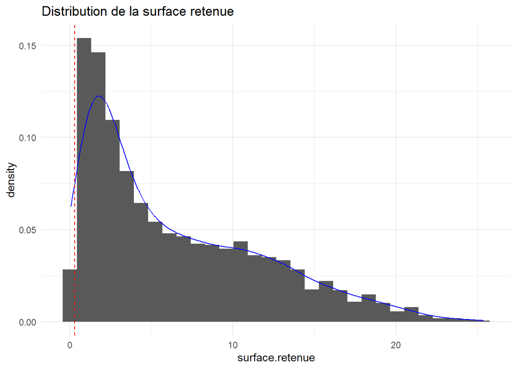

En rouge la taille maximale d’un patch forceeps. Pour les petites parcelles on peut peut-être concidérer que les deux peuplement cohabitent mais sinon ça n’est peut-être pas pertinent de faire la moyenne sur les peuplements.

# Reserve utile

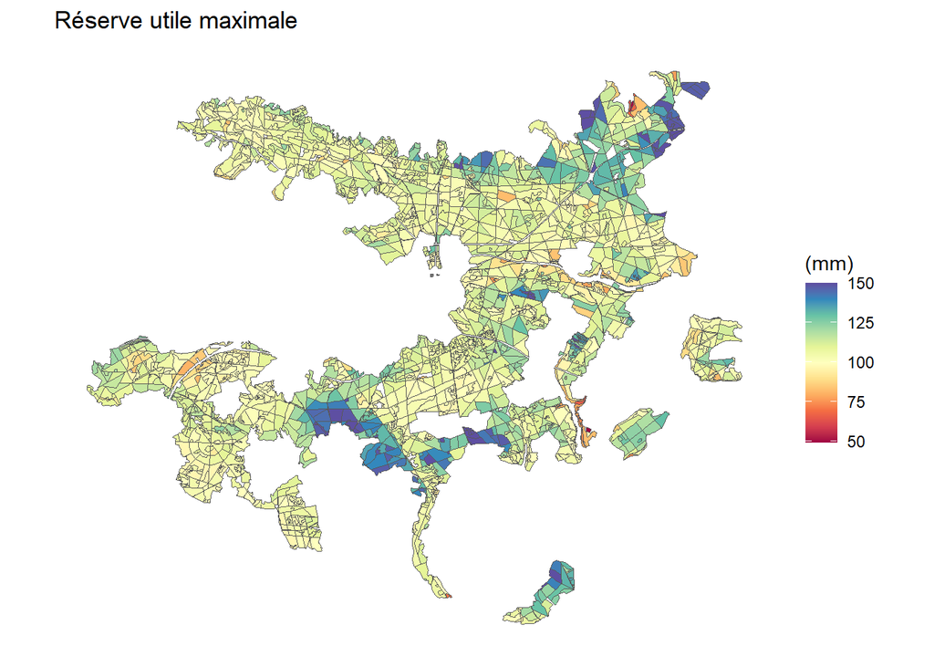

```r
ggplot(forest_data) +
  geom_sf(aes(geometry = geometry, fill = RUM)) +
  theme_minimal() +
  theme(
    panel.grid = element_blank(),
    axis.text.x = element_blank(),
    axis.text.y = element_blank())+
  scale_fill_gradientn(colours = (brewer.pal(11, "Spectral"))) +
  labs(title = "Réserve utile maximale", fill = "(mm)")
```